# 实验背景

风险已经成为了今年金融市场的重要主题之一，银行作为贷方，随时都面临着借贷者违约的风险。传统的专家规则在金融科技时代逐渐过时，机器学习和金融业务的交叉也延伸到信贷领域。违约预测就是其中一重要应用。本实验基于信贷业务场景中某一个月的抽样数据，数据有34个维度，Target表示客户在接下来一个月是否有违约,分别用0和1表示。模型生成后可使用当前月的数据预测接下来一个月客户是否会违约。

[figure not shown]

# 实验总体概览

违约预测只有违约和没有违约两种结果，是个二分类问题。针对二分类问题，可使用的算法有逻辑斯谛回归、朴素贝叶斯、感知机、支持向量机、树模型等。考虑到实验的完整性和实用性，本实验选用业界常用的逻辑斯谛回归（广义线性模型）和随机森林（集成树模型）来做对比。考虑到样本极度不均衡，最终的模型评价选用综合指标f1_score（精确率和召回率的平衡）。

# 实验详细实现流程

## 导入实验环境

```python
#要求导入相关数据读取、处理、分析、可视化，算法模块等
import pandas as pd
import numpy as np
#导入相关包
%matplotlib inline
import seaborn as sns
import matplotlib.pyplot as plt
import warnings
warnings.filterwarnings("ignore")
```

## 数据准备

- 数据获取及查看
- 数据预处理及特征工程

### 数据获取及查看

```python
path="dataset-credit-default.csv"
df = pd.read_csv(path,encoding='utf-8')#
df.head()
```

|  | Cust_No | Target | Nation | Birth_Place | Gender | Age | Marriage_State | Highest Education | House_State | Work_Years | ... | ZX_Max_Overdue_Account | ZX_Link_Max_Overdue_Amount | ZX_Total_Overdu_Months | ZX_Max_Overdue_Duration | ZX_Max_Credits | ZX_Max_Credit_Banks | ZX_Max_Overdue_Credits | ZX_Credit_Max_Overdu_Amount | ZX_Credit_Total_Overdue_Months | ZX_Credit_Max_Overdue_Duration |
| --- | --- | --- | --- | --- | --- | --- | --- | --- | --- | --- | --- | --- | --- | --- | --- | --- | --- | --- | --- | --- | --- |
| 0 | 0 | 0 | 1.0 | 330621 | 1 | 41 | 20.0 | 61.0 | NaN | 0 | ... | 1 | 8 | 1 | 1 | 0 | 0 | 0 | 0 | 0 | 0 |
| 1 | 1 | 0 | 1.0 | 330621 | 1 | 41 | 20.0 | 71.0 | 1.0 | 0 | ... | 1 | 0 | 3 | 1 | 2 | 1 | 0 | 0 | 0 | 0 |
| 2 | 2 | 0 | 1.0 | 330621 | 1 | 55 | 40.0 | 71.0 | 1.0 | 0 | ... | 1 | 0 | 2 | 1 | 1 | 1 | 0 | 0 | 0 | 0 |
| 3 | 3 | 0 | 1.0 | 330621 | 1 | 41 | 20.0 | 61.0 | 1.0 | 68624 | ... | 0 | 0 | 0 | 0 | 1 | 1 | 0 | 0 | 0 | 0 |
| 4 | 4 | 0 | 1.0 | 330621 | 0 | 40 | 99.0 | 90.0 | 1.0 | 0 | ... | 0 | 0 | 0 | 0 | 0 | 0 | 0 | 0 | 0 | 0 |

5 rows × 34 columns

一共有33个特征以及一个标签

其中标签是Target,特征包括nation(国家）、birth_place（出生地），gender（性别），age（年龄）等

```python
##查看Target的分布 ,是否违约（1是，0否）
df['Target'].value_counts()
```

```
0    6341
1     121
Name: Target, dtype: int64
```

可以看到，不违约的样本有6341个，违约的有121个，属于不均衡数据集

### 数据处理

#### 特征工程

由于变量数量较多，首先我们进行特征工程，对变量做一个筛选。

通过相关性分析,可视化观察特征相关性，对于相关性过高的的特征，删除其中一个（根据工程经验，以0.8为界）

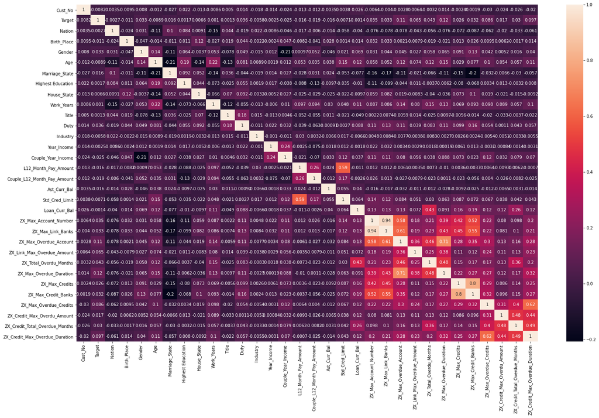

```python
#计算特征相关性
corr_matrix = df.corr(method='spearman')
corr_matrix1 = df.corr(method='pearson')
#可视化
plt.figure(figsize=(25, 15))
sns.heatmap(corr_matrix, annot= True)#使用seaborn库的heatmap函数画热力图,annot= True表示在每个方格里显示具体数值
```

存储相关性过高的特征对,对于相关性过高的的特征，删除其中一个：

```python
# 选择出符合内容的单元格对应的行、列标签
cols_pair_to_drop = []
for index_ in corr_matrix.index:
    for col_ in corr_matrix.columns:
        if corr_matrix.loc[index_,col_] >= 0.8 and index_!=col_ and (col_,index_) not in cols_pair_to_drop:#筛选出相关性>0.8的特征对
            cols_pair_to_drop.append((index_,col_))
print(cols_pair_to_drop)
```

```
[('ZX_Max_Account_Number', 'ZX_Max_Link_Banks'), ('ZX_Max_Credits', 'ZX_Max_Credit_Banks')]
```

```python
#丢弃特征对中的一个
cols_to_drop = np.unique([col[1] for col in cols_pair_to_drop])  #对于一维数组或者列表，unique函数去除其中重复的元素，并按元素由大到小返回一个新的无元素重复的元组或者列表
df.drop(cols_to_drop,axis=1,inplace=True)
df.head()
```

|  | Cust_No | Target | Nation | Birth_Place | Gender | Age | Marriage_State | Highest Education | House_State | Work_Years | ... | ZX_Max_Account_Number | ZX_Max_Overdue_Account | ZX_Link_Max_Overdue_Amount | ZX_Total_Overdu_Months | ZX_Max_Overdue_Duration | ZX_Max_Credits | ZX_Max_Overdue_Credits | ZX_Credit_Max_Overdu_Amount | ZX_Credit_Total_Overdue_Months | ZX_Credit_Max_Overdue_Duration |
| --- | --- | --- | --- | --- | --- | --- | --- | --- | --- | --- | --- | --- | --- | --- | --- | --- | --- | --- | --- | --- | --- |
| 0 | 0 | 0 | 1.0 | 330621 | 1 | 41 | 20.0 | 61.0 | NaN | 0 | ... | 0 | 1 | 8 | 1 | 1 | 0 | 0 | 0 | 0 | 0 |
| 1 | 1 | 0 | 1.0 | 330621 | 1 | 41 | 20.0 | 71.0 | 1.0 | 0 | ... | 2 | 1 | 0 | 3 | 1 | 2 | 0 | 0 | 0 | 0 |
| 2 | 2 | 0 | 1.0 | 330621 | 1 | 55 | 40.0 | 71.0 | 1.0 | 0 | ... | 2 | 1 | 0 | 2 | 1 | 1 | 0 | 0 | 0 | 0 |
| 3 | 3 | 0 | 1.0 | 330621 | 1 | 41 | 20.0 | 61.0 | 1.0 | 68624 | ... | 1 | 0 | 0 | 0 | 0 | 1 | 0 | 0 | 0 | 0 |
| 4 | 4 | 0 | 1.0 | 330621 | 0 | 40 | 99.0 | 90.0 | 1.0 | 0 | ... | 4 | 0 | 0 | 0 | 0 | 0 | 0 | 0 | 0 | 0 |

5 rows × 32 columns

#### 数据预处理

数据预处理包括缺失值处理和异常值处理，而本实验中数据分为数值型变量和名义型变量，他们的处理方式各有不同。

首先来看数值型变量的异常值和缺失值处理：

打印出缺失率最高的前15个特征以及对应的缺失率：

```python
df_missing_stat = pd.DataFrame(df.isnull().sum()/df.shape[0],columns=['missing_rate']).reset_index()
# df_missing_stat
df_missing_stat.sort_values(by='missing_rate',ascending=False)[:15]
```

|  | index | missing_rate |
| --- | --- | --- |
| 16 | Couple_Year_Income | 0.689260 |
| 18 | Couple_L12_Month_Pay_Amount | 0.689260 |
| 10 | Unit_Kind | 0.621634 |
| 11 | Title | 0.571804 |
| 14 | Industry | 0.564222 |
| 12 | Occupation | 0.555091 |
| 8 | House_State | 0.397864 |
| 2 | Nation | 0.330703 |
| 6 | Marriage_State | 0.309037 |
| 7 | Highest Education | 0.299133 |
| 13 | Duty | 0.119003 |
| 26 | ZX_Max_Overdue_Duration | 0.000000 |
| 23 | ZX_Max_Overdue_Account | 0.000000 |
| 24 | ZX_Link_Max_Overdue_Amount | 0.000000 |
| 25 | ZX_Total_Overdu_Months | 0.000000 |

sort_values（）是pandas中比较常用的排序方法，其主要涉及以下三个参数：

- by : str or list of str（字符或者字符列表）
- ascending : bool or list of bool, default True （是否升序排序，默认为true，降序则为false。如果是列表，则需和by指定的列表数量相同，指明每一列的排序方式）
- na_position : {‘first’, ‘last’}, default ‘last’ （即如果指定排序的列中有nan值，则指定nan值放在第一个还是最后一个）

可以看出缺失率最高的是Couple_Year_Income、Couple_L12_Month_Pay_Amount、Unit_Kind、Title、Industry和Occupation ，缺失率都超过了50%。其中，Couple_Year_Income和Couple_L12_Month_Pay_Amount是数值型变量；而Unit_Kind、Title、Industry和Occupation是名义型变量。

针对Couple_Year_Income和Couple_L12_Month_Pay_Amount，需要先可视化来判定下如何填充。

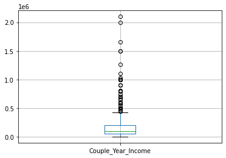

```python
df.boxplot(column=['Couple_Year_Income'])
```

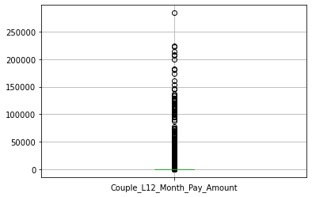

```python
df.boxplot(column=['Couple_L12_Month_Pay_Amount'])
```

从上面箱线图可以看出Couple_Year_Income和Couple_L12_Month_Pay_Amount异常值比例都不低，且缺失率很高，可以在删除带有异常值的样本的基础上，再来进行缺失值的填充。一般有两种选择：尝试用中位数（对数值型变量常用且在该业务场景下，使用中位数也符合实际的分布）来填充缺失值；或者直接删除。本实验尝试第一种。

```python
#删除Couple_Year_Income的异常值并用中位数填补缺失值
item = 'Couple_Year_Income'
iqr = df[item].quantile(0.75) - df[item].quantile(0.25)
#iqr即Inter-Quartile Range, 这是统计技术上的名词.称为内距或四分位差
#是两个四分位数之差,即内距iqr=高四分位数—低四分位数

q_abnormal_L = df[item] < df[item].quantile(0.25) - 1.5 * iqr
#q_abnormal_L表示Couple_Year_Income中比下四分位数减去1.5 * 内距还要小的样本数，这样的样本可以认为是异常值
q_abnormal_U = df[item] > df[item].quantile(0.75) + 1.5 * iqr
#同理，q_abnormal_U也表示特别大的异常值的数量

#取异常点的索引
print(item + '中有' + str(q_abnormal_L.sum() + q_abnormal_U.sum()) + '个异常值')
item_outlier_index = df[q_abnormal_L|q_abnormal_U].index

###删除异常值
df.drop(index = item_outlier_index,inplace=True)
print(df.shape)
```

```
Couple_Year_Income中有131个异常值
(6331, 32)
```

```python
#用中位数填补缺失值
df[item] = df[item].fillna(df[item].median())

#删除Couple_L12_Month_Pay_Amount的异常值并用中位数填补缺失值
item = 'Couple_L12_Month_Pay_Amount'
iqr = df[item].quantile(0.75) - df[item].quantile(0.25)
q_abnormal_L = df[item] < df[item].quantile(0.25) - 1.5 * iqr
q_abnormal_U = df[item] > df[item].quantile(0.75) + 1.5 * iqr
#取异常点的索引
print(item + '中有' + str(q_abnormal_L.sum() + q_abnormal_U.sum()) + '个异常值')
item_outlier_index = df[q_abnormal_L|q_abnormal_U].index
df.drop(index = item_outlier_index,inplace=True)
print(df.shape)
df[item] = df[item].fillna(df[item].median())
```

```
Couple_L12_Month_Pay_Amount中有372个异常值
(5959, 32)
```

##### 名义型变量缺失值处理

名义型变量缺失值，Unit_Kind、Title、Industry和Occupation，先查看其分布。

```
1000    1802
1175     179
9999      63
2000      29
1172      16
1120       6
Da         1
ae         1
Be         1
Name: Unit_Kind, dtype: int64
9.0    1704
0.0     497
3.0      79
2.0      76
1.0      26
Name: Title, dtype: int64
```

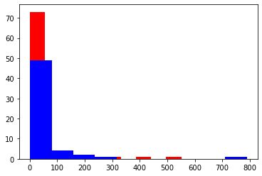

```python
#工作单位性质
print(df['Unit_Kind'].value_counts())#value_counts函数可以看各个取值及数量
#职务
print(df['Title'].value_counts())
#行业，取值较多，使用柱状图展示，用红色表示
plt.hist(df['Industry'].value_counts(),color='r')
#职务，取值较多，使用柱状图展示，用蓝色表示
plt.hist(df['Occupation'].value_counts(),color='b')
```

```python
### 查看df中仍有少量缺失值的特征
null_col=[]
for col in df.columns:
    if df[col].isnull().sum()>0:
        null_col.append(col)
null_col
```

```
['Nation',
 'Marriage_State',
 'Highest Education',
 'House_State',
 'Unit_Kind',
 'Title',
 'Occupation',
 'Duty',
 'Industry']
```

```python
###使用众数填充缺失值
for col_to_fill in null_col:
    df[col_to_fill] = df[col_to_fill].fillna(df[col_to_fill].mode()[0]) #选择每个特征出现频率对高的第一个属性值进行填充
```

```python
### 删除无分类意义的特征列Cust_No
del df['Cust_No']
```

##### 对名义型变量做标签编码

```python
### 查看数据集剩余的名称性特征
con_col=[]
for col in df.columns:
    if df.dtypes[col] == np.object:
        con_col.append(col)
con_col
```

```
['Unit_Kind', 'Occupation']
```

```python
df['Unit_Kind'] = pd.factorize(df['Unit_Kind'])[0] #factorize是编码函数，将字符型数据编码为数值型
df['Occupation'] = pd.factorize(df['Occupation'])[0]
```

```python
df.info()
```

```
<class 'pandas.core.frame.DataFrame'>
Int64Index: 5959 entries, 2 to 6460
Data columns (total 31 columns):
 #   Column                          Non-Null Count  Dtype
---  ------                          --------------  -----
 0   Target                          5959 non-null   int64
 1   Nation                          5959 non-null   float64
 2   Birth_Place                     5959 non-null   int64
 3   Gender                          5959 non-null   int64
 4   Age                             5959 non-null   int64
 5   Marriage_State                  5959 non-null   float64
 6   Highest Education               5959 non-null   float64
 7   House_State                     5959 non-null   float64
 8   Work_Years                      5959 non-null   int64
 9   Unit_Kind                       5959 non-null   int64
```

[output cut: 23 more lines]

#### 数据集划分

将数据集作9:1的切分（传统的使用二八分或者三七分，但此处样本量有5959条，测试集保留500多条就可以评价模型），训练集共5259条负样本，104条正样本；测试集共584条负样本，12条正样本。

```python
x_cols = [col for col in df.columns if col!='Target']
y_col = 'Target'
```

```python
from sklearn.model_selection import train_test_split
from collections import Counter
X_train, X_test, y_train, y_test = train_test_split(df[x_cols],
                    df[y_col],
                    test_size=0.1, #分割比例
                    random_state=42, #随机数种子
                    shuffle=True, #是否打乱顺序
     stratify=df[y_col])      #指定以Target的比例做分层抽样
print('Distribution of y_train {}'.format(Counter(y_train)))
print('Distribution of y_test {}'.format(Counter(y_test)))
```

```
Distribution of y_train Counter({0: 5259, 1: 104})
Distribution of y_test Counter({0: 584, 1: 12})
```

```python
# 引入StandardScaler标准化工具库
from sklearn.preprocessing import StandardScaler
#对训练集和测试集做标准化
std_scaler = StandardScaler().fit(df[x_cols])
X_train_std = std_scaler.transform(X_train)
X_test_std = std_scaler.transform(X_test)
```

## 建模分析

- Logistic Regression模型
- randomforest模型

### **Logistic Regression模型**

#### 导入建模所需库

```python
#引入逻辑斯谛回归和特征选择的库
from sklearn.linear_model import LogisticRegression,LogisticRegressionCV
#引入评价指标的库
from sklearn.metrics import accuracy_score #准确率
from sklearn.metrics import f1_score #f1_score
from sklearn.metrics import recall_score #召回率
from sklearn.metrics import precision_score#预测准确率
```

#### 建立模型，查看评价指标

```python
#建立逻辑斯谛回归模型，并进行训练和预测
lr_model = LogisticRegression()
lr_model.fit( X_train_std, y_train)
y_test_pred1 = lr_model.predict(X_test_std)
```

```python
#查看评价指标
print('accuracy of lr_model score',accuracy_score(y_test, y_test_pred1))
print('f1_score of lr_model score',f1_score(y_test, y_test_pred1))
print('recall_score of lr_model score',recall_score(y_test, y_test_pred1))
print('precision_score of lr_model score',precision_score(y_test, y_test_pred1))
```

```
accuracy of lr_model score 0.9798657718120806
f1_score of lr_model score 0.0
recall_score of lr_model score 0.0
precision_score of lr_model score 0.0
```

#### 过采样及交叉验证评估原始模型

因为样本过于不均衡，首先进行过采样。过采样的方法主要有两种，一种是smote算法，另一种是ADASYN算法。

什么是过采样：

```
目的：处理数据不平衡问题
方法：当数据不平衡的时，比如样本标签1有10000个数据，样本标签0有100个数据，这时如果正常采样会浪费很多样本
所以引入过采样，过采样是根据样本标签少的样本的规律去生成更多该标签样本，这样使得数据趋向于平衡。
```

过采样常用的方法是smote方法和ADASYN方法。

smote基本思想：对于少数类样本a, 随机选择一个最近邻的样本b, 然后从a与b的连线上随机选取一个点c作为新的少数类样本。

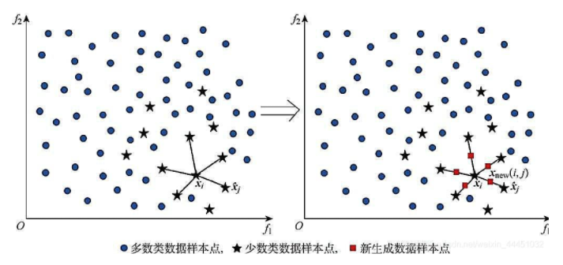

ADASYN基本思想：

ADASYN是自适应综合过采样方法，ADASYN算法的关键思想是使用密度分布作为准则来自动确定每个少数数据实例需要生成的合成样本的数量，即在少数样本的密度较低的特征空间区域中生成更多的合成实例，而在密度较高的特征空间区域生成较少的合成实例。 综合来看，ADASYN就是自适应地将分类决策边界向数量较少的实例移动，从而减少类不平衡带来的偏差。

接下来我们分别使用smote方法和ADASYN方法来进行交叉验证，并进行性能的比较：

smote算法：

```python
from imblearn import over_sampling#导入过采样模块
print('Original dataset shape {}'.format(Counter(y_train)))
#ratio指定过采样比例，此处为2:1
smote_model = over_sampling.SMOTE(random_state=7)
X_train_res,y_train_res = smote_model.fit_resample(X_train_std,y_train)
print('Resampled dataset shape {}'.format(Counter(y_train_res)))
```

```
Original dataset shape Counter({0: 5259, 1: 104})
Resampled dataset shape Counter({0: 5259, 1: 5259})
```

ADASYN算法：

```python
from collections import Counter
from imblearn.over_sampling import ADASYN

print('Original dataset shape %s' % Counter(y_train))
ada = ADASYN(random_state=42)
X_res, y_res = ada.fit_resample(X_train_std, y_train)
print('Resampled dataset shape %s' % Counter(y_res))
```

```
Original dataset shape Counter({0: 5259, 1: 104})
Resampled dataset shape Counter({0: 5259, 1: 5241})
```

https://www.cnblogs.com/massquantity/p/9382710.html

以下得到交叉验证的结果：

使用sklearn.linear_model.LogisticRegression分类器。

- 使用smote过采样的结果：

```python
from sklearn.model_selection import cross_val_score
cv_scores = cross_val_score(lr_model, X_train_res, y_train_res,  cv=5)
print('cross validation score of model version1 {}'.format(cv_scores))
```

```
cross validation score of model version1 [0.69391635 0.68441065 0.67205323 0.69091774 0.68188302]
```

- 使用ADASYN方法过采样的结果：

```python
from sklearn.model_selection import cross_val_score
cv_scores = cross_val_score(lr_model, X_res, y_res,  cv=5)
print('cross validation score of model version1 {}'.format(cv_scores))
```

```
cross validation score of model version1 [0.68238095 0.65952381 0.64047619 0.66428571 0.69428571]
```

对比smote和ADASYN方法交叉验证的结果发现，smote方法的效果要更好一些，因此我们选择使用smote方法进行过采样。

#### 逻辑回归调参

Logistic Regression中可调的参数有正则化系数（C）、正则化系数（penalty）、优化算法（solver）、类型权重参数（class_weight）、样本权重参数（sample_weight）等。本次调节常用的C和solver两个参数，使用网格搜索法（本步骤耗时预计5分钟，可能会报不收敛就达到最大迭代次数的告警，请忽略）。

```python
from sklearn.model_selection import GridSearchCV

#设置网格搜索训练的各个参数范围
c_range=[0.001,0.01,0.1,1.0]
solvers = ['liblinear','lbfgs','newton-cg','sag']#选择四种不同的优化算法类型，通过交叉验证来选择最好的
tuned_parameters = dict(solver=solvers, C=c_range)

#网格搜索+交叉验证
grid= GridSearchCV(lr_model, param_grid=tuned_parameters,cv=5)
grid.fit(X_train_res,y_train_res)
print('best score for model {}'.format(grid.best_score_))
print('best parameters for model {}'.format(grid.best_params_))
```

```
best score for model 0.6846361977909523
best parameters for model {'C': 1.0, 'solver': 'liblinear'}
```

**GridSearchCV参数介绍**：

class sklearn.model_selection.GridSearchCV(estimator, param_grid, scoring=None, fit_params=None, n_jobs=1, iid=True, refit=True, cv=None, verbose=0, pre_dispatch=‘2*n_jobs’, error_score=’raise’, return_train_score=’warn’)

重要参数：

（1） estimator

很重要，选择使用的分类器，并且传入除需要确定最佳的参数之外的其他参数。每一个分类器都需要一个scoring参数，或者score方法，例如：estimator=RandomForestClassifier(min_samples_split=100,min_samples_leaf=20,max_depth=8,max_features='sqrt',random_state=10),

（2） param_grid

需要最优化的参数的取值，值为字典或者列表，例如：param_grid =param_test1，param_test1 = {'n_estimators':range(10,71,10)}。

（3） cv

表示几折交叉验证，cv的可能输入有:

- None，使用默认的3倍交叉验证，
- integer，用于指定“(分层)KFold”中的折叠数， -用作交叉验证生成器的对象。 -一个迭代的屈服序列，测试分裂。

**solver优化算法类型：**

a) liblinear：使用了开源的liblinear库实现，内部使用了坐标轴下降法来迭代优化损失函数。  
b) lbfgs：拟牛顿法的一种，利用损失函数二阶导数矩阵即海森矩阵来迭代优化损失函数。  
c) newton-cg：也是牛顿法家族的一种，利用损失函数二阶导数矩阵即海森矩阵来迭代优化损失函数。  
d) sag：即随机平均梯度下降，是梯度下降法的变种，和普通梯度下降法的区别是每次迭代仅仅用一部分的样本来计算梯度，适合于样本数据多的时候。

在优化参数的选择上，官方是这样建议的：  
e）saga：优化的，无偏估计的sag方法。（‘sag’ uses a Stochastic Average Gradient descent, and ‘saga’ uses its improved, unbiased version named SAGA.）  
对小的数据集，可以选择"liblinear"，如果是大的数据集，比如说大于10W的数据，那么选择"sag"和"saga"会让训练速度更快。  
对于多分类问题，只有newton-cg,sag,saga和lbfgs能够处理多项损失（也就是MvM的情况，还记得上面说到的多分类嘛？），而liblinear仅处理(OvR)的情况。啥意思，就是用liblinear的时候，如果是多分类问题，得先把一种类别作为一个类别，剩余的所有类别作为另外一个类别。一次类推，遍历所有类别，进行分类。

#### 逻辑回归模型效果评估

```python
### 依据最佳模型重新训练模型
grid.best_estimator_.fit(X_train_res,y_train_res)

### 查看逻辑回归模型在测试集上的效果
y_test_pred2 = grid.best_estimator_.predict(X_test_std)
print('accuracy of lr_model score',accuracy_score(y_test, y_test_pred2))
print('f1_score of lr_model score',f1_score(y_test, y_test_pred2))
print('recall_score of lr_model score',recall_score(y_test, y_test_pred2))
print('precision_score of lr_model score',precision_score(y_test, y_test_pred2))
```

```
accuracy of lr_model score 0.6963087248322147
f1_score of lr_model score 0.08121827411167513
recall_score of lr_model score 0.6666666666666666
precision_score of lr_model score 0.043243243243243246
```

从模型结果看，过采样方法一定程度上可以提高逻辑回归模型在**召回率**等指标的得分，但是分值仍很低，考虑到训练与测试数据规模均非常小测试集特别是过抽样会加大过拟合风险。如果需要提升模型性能需要**进一步增加样本、尝试其他算法**来拟合数据。下面尝试使用随机森林。

### RandomForest模型

#### 不均衡样本处理：随机森林等带有样本权重调节参数的算法

一、**class_weight参数** : 分类模型中各种类型的权重，可以不输入，即不考虑权重，或者说所有类型的权重一样。

- 手动输入各个类型的权重：  
  比如对于0,1的二元模型，定义class_weight={0:0.8, 1:0.2}，即表示类型0的权重为80%，而类型1的权重为20%.
- 选择balanced：  
  类库根据训练样本量计算权重，样本数目越多，权重越小，样本数越少，权重越大。计算方法如下：  
  n_samples / (n_classes * np.bincount(y))  
  其中，n_samples为样本数，n_classes为类别数量，np.bincount(y)会输出每个类的样本数，例如y=[1,0,0,0,0],则 np.bincount(y)=[4,1]

什么场景下用class_weight?

- 误分类代价高： 如信用卡欺诈、乳腺癌检测等（将欺诈和阳性设为label 1），可适当提高label 1的权重
- 样本高度不平衡： 比如信用卡欺诈场景中，正常交易有280000次，欺诈有28次。如果不考虑权重，则将所有测试集都预测为正常交易，这样预测准确率理论上将大于99.99%，但是却没有任何意义。这时，可以选择balanced，让类库自动提高欺诈交易样本的权重。

样本高度不平衡的情况还可以考虑参数sample_weight：

二、**sample_weight** (fit函数的参数)  
当样本是高度失衡的，导致样本不是总体样本的无偏估计，从而可能导致模型预测能力下降。这种情况，可以通过调节样本权重来尝试解决这个问题。

调节样本权重的方法有两种：  
（1）在class_weight使用balanced。  
（2）调用fit函数时，通过sample_weight来调节每个样本权重。  
在scikit-learn做逻辑回归时，如果上面两种方法都用到了，那么样本的真正权重是class_weight*sample_weight.

https://blog.csdn.net/weixin_43685844/article/details/88831907

#### 建立模型，得出评价指标结果

```python
RandomForestClassifier?
```

```
Object `RandomForestClassifier` not found.
```

```python
### 先初始化几个参数，尝试训练下
from sklearn.ensemble import RandomForestClassifier
from sklearn.metrics import recall_score,roc_auc_score,make_scorer,f1_score
from sklearn.model_selection import cross_val_score,GridSearchCV

#尝试使用20颗树，后续根据需要再改变树的数量
rf_model = RandomForestClassifier(n_estimators=20)
rf_model.fit(X_train_std, y_train)
y_test_pred3 = rf_model.predict(X_test_std)
print('accuracy of rf_model score',accuracy_score(y_test, y_test_pred3))
print('f1_score of rf_model score',f1_score(y_test, y_test_pred3))
print('recall_score of rf_model score',recall_score(y_test, y_test_pred3))
print('precision_score of rf_model score',precision_score(y_test, y_test_pred3))
```

```
accuracy of rf_model score 0.9832214765100671
f1_score of rf_model score 0.2857142857142857
recall_score of rf_model score 0.16666666666666666
precision_score of rf_model score 1.0
```

### 调参

```python
### 对class_weight进行搜索
param_test0 = {'class_weight':[{0:1,1:3},{0:1,1:5},{0:1,1:10},{0:1,1:20},'balanced']}
#这里要根据交叉验证选择class_weight的取值
#指定各个样本的权重如果使用“balanced”，则算法会自己计算权重
gsearch0 = GridSearchCV(
    estimator = rf_model,
    param_grid = param_test0,
    cv=5
    )
gsearch0.fit(X_train_std,y_train)
print('best params:{}'.format(gsearch0.best_params_))
print('best score:{}'.format(gsearch0.best_score_))
```

```
best params:{'class_weight': {0: 1, 1: 3}}
best score:0.9809809294626588
```

```python
### 对n_estimators进行搜索
param_test1 = {'n_estimators':range(10,101,10)}
gsearch1 = GridSearchCV(
    estimator = gsearch0.best_estimator_,
    param_grid = param_test1,
    cv=5
    )
gsearch1.fit(X_train_std,y_train)
print('best params:{}'.format(gsearch1.best_params_))
print('best score:{}'.format(gsearch1.best_score_))
```

```
best params:{'n_estimators': 20}
best score:0.9809809294626588
```

我们得到了最佳的决策树数为20，目前的随机森林有过拟合倾向，因为叶子最小样本数、最小分割样本数、最大深度等都是None，没有剪枝操作。

```python
### 比较它与逻辑斯谛回归在测试集上的效果
y_test_final = gsearch1.best_estimator_.predict(X_test_std)
print('accuracy of rf_model score',accuracy_score(y_test, y_test_final))
print('f1_score of rf_model score',f1_score(y_test, y_test_final))
print('recall_score of rf_model score',recall_score(y_test,y_test_final))
print('precision_score of rf_model score',precision_score(y_test, y_test_final))
```

```
accuracy of rf_model score 0.9832214765100671
f1_score of rf_model score 0.2857142857142857
recall_score of rf_model score 0.16666666666666666
precision_score of rf_model score 1.0
```

# 总结分析

通过本实验，我们主要学习了：

- 使用Python进行数据预处理、数据分析
- 使用seaborn做可视化分析
- 使用SMOTE方法来过采样
- 使用逻辑斯谛回归和随机森林建模
- 使用网格搜索来寻找最优参数组合

违约预测问题面临着所需数据维度多、正负样本严重不均衡等问题，在实际应用上，可以多搜集各类维度的特征，多尝试过采样、欠采样，也可以尝试使用无监督学习、深度神经网络等。